# MAPAS

Grupo Idealista

16/5/2022

- Nota: las visualizaciones que tienen planos (dónde se ven las calles y zonas verdes) son interactivas (se pueden ampliar y pinchar sobre los puntos).

# 1 Precio de las casas vendidas

Empezamos graficando los precios de las casas vendidas. Para ello, vamos a discretizar la variable precio en 6 intervalos de igual frecuencia.

Observamos que las casas más caras se encuentran en torno al centro de Valencia, especialmente en el distrito Ciutat Vella. También nos encontramos que el distrito Campanar alberga casas caras, quizás esto se deba a que es un distrito nuevo en construcción y por ende tiene construidas más urbanizaciones.

En cuanto a los pisos baratos, se encuentran en las afueras de Valencia, a los alrededores. El motivo es que estas zonas están menos comunicadas y no se venden tanto. Sin embargo, el puerto de Valencia, a pesar de estar en las afueras, no presenta muchas pisos baratos. Probablemente estas viviendas no son pisos como tal, sino chalets de lujo al lado de la playa.

```r
vendidos = read.csv('pisosR.csv', sep = ',')
la = vendidos$latitude
lo = vendidos$longitude

valencia = data.frame(lat = la, lng = lo)

precios = vendidos$precio_final
vendidos$priceClass = discretize(precios, method='frequency', breaks=6, labels=c('29300-98000', '99000-139000', '139900-180000', '181000-244600', '245000-359000', '360000-3300000'))


pale = rainbow(6)
leaflet(valencia) %>%
  addTiles() %>%
  addCircles(weight = 3 # grosor de circulos
             ,radius = 4, # radio de los circulos proporcional a la clase perteneciente
             color = pale[vendidos$priceClass], # color diferenciador de clases
             popup = as.character(vendidos$priceClass))%>%
  addLegend(position = "bottomleft" ,colors = pale,
            labels = paste("-->", c('29300-98000', '99000-139000', '139900-180000', '181000-244600', '245000-359000', '360000-3300000')),title = "Etiqueta")
```

[interactive chart not shown]

# 2 Metros cuadrados de las casas vendidas

Por lo que respecta a los metros cuadrados de las casas vendidas, se aprecia que, como era de esperar, las casas más caras suelen tener más metros cuadrados. Por ello, las viviendas más grandes se encuentran de nuevo en el centro, Campanar y la zona de la playa.

Así, los pisos más pequeños se encuentran en las afueras de Valencia.

En general, todos los distritos tienen viviendas que superan los 70 metros cuadrados.

[interactive chart not shown]

# 3 Variables por distrito

A continuación pasamos a graficar las variables de distritos_info. Para ello, mediante un fichero shp, hemos creado el controno de la ciudad de Valencia, dividida por distritos.

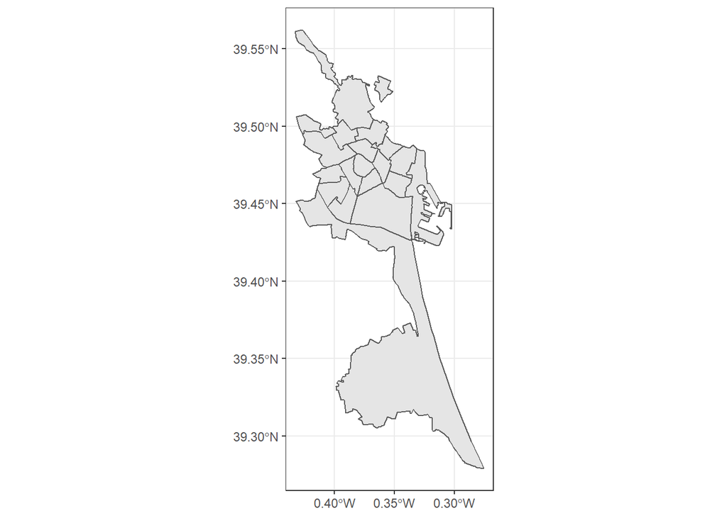

```r
peninbal_shp_filename3 <- glue("distritos.shp")
peninbal_shp3 <- read_sf(peninbal_shp_filename3, quiet = TRUE)

peninbal_shp3 %>%
  ggplot() +
  geom_sf() +
  theme_bw()
```

```r
distritos = read.csv('distritos_info.csv', sep = ';')

distritos$distrito[distritos$distrito == 'la saïdia'] = 'La Saidia'
distritos$distrito[distritos$distrito == 'patraix'] = 'Patraix'
distritos$distrito[distritos$distrito == "pobles de l'oest"] = "Poblats de l'Oest"
distritos$distrito[distritos$distrito == 'pobles del nord'] = 'Poblats del Nord'
distritos$distrito[distritos$distrito == 'pobles del sud'] = 'Poblats del Sud'
distritos$distrito[distritos$distrito == 'poblats marítims'] = 'Poblats Maritims'
distritos$distrito[distritos$distrito == 'quatre carreres'] = 'Quatre Carreres'
distritos$distrito[distritos$distrito == 'rascanya'] = 'Rascanya'
distritos$distrito[distritos$distrito == 'algirós'] = 'Algiros'
distritos$distrito[distritos$distrito == 'benicalap'] = 'Benicalap'
distritos$distrito[distritos$distrito == 'benimaclet'] = 'Benimaclet'
distritos$distrito[distritos$distrito == 'camins al grau'] = 'Camins al Grau'
distritos$distrito[distritos$distrito == 'campanar'] = 'Campanar'
distritos$distrito[distritos$distrito == 'ciutat vella'] = 'Ciutat Vella'
distritos$distrito[distritos$distrito == 'el pla del real'] = 'El Pla del Real'
distritos$distrito[distritos$distrito == 'extramurs'] = 'Extramurs'
distritos$distrito[distritos$distrito == 'jesús'] = 'Jesus'
distritos$distrito[distritos$distrito == "l'eixample"] = "l'Eixample"
distritos$distrito[distritos$distrito == "l'olivereta"] = "l'Olivereta"
```

## 3.1 Valor metro cuadrado catastro

A continuación representamos el valor del metro cuadrado según el catastro. Observamos que los distritos más céntricos, como son Ciutat Vella, Pla del Real y L’Eixample son los que mayor valor catastral tienen. Concretamente, el Pla del Real tiene el valor de metro cuadrado más alto registrado (superando los 600€).

El distrito con menor valor catastral es Poblats del Nord. Esto se debe a que se trata de un distrito con muchas pedanías, y quizás el valor metro cuadrado no esté tan demandado.

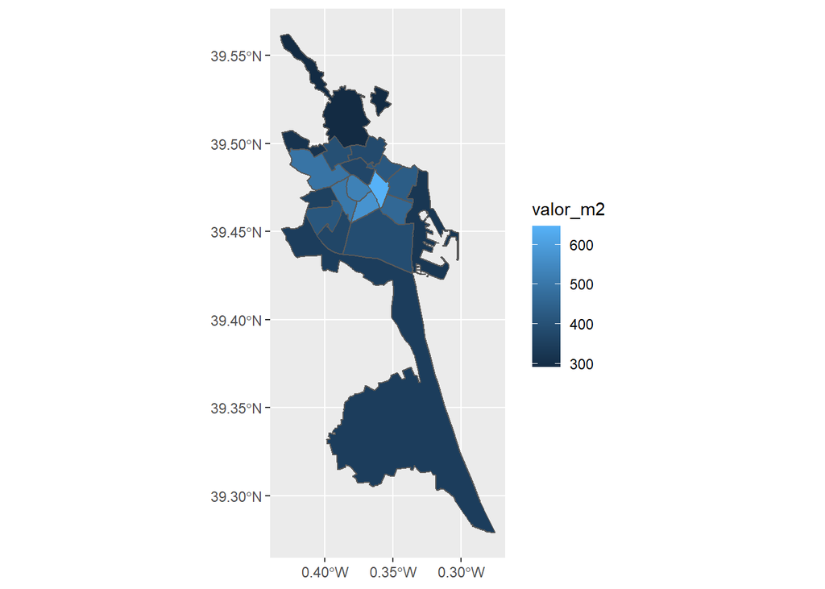

```r
m2 = data.frame(distrito = distritos$distrito, valor_m2 = distritos$valor_m2)

drawing_data <-
  peninbal_shp3 %>%
  mutate(distrito = name) %>%
  left_join(m2, by = 'distrito')


drawing_data %>%
  ggplot() +
  aes(fill = `valor_m2`) +
  geom_sf()
```

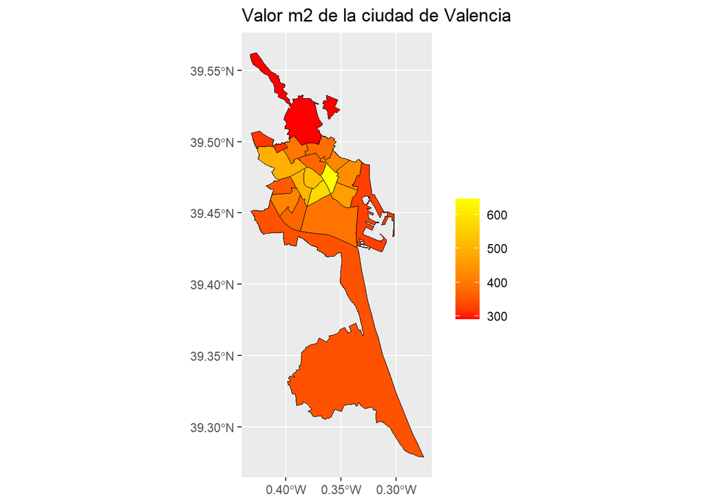

```r
map <-
  drawing_data %>%
  ggplot() +
  aes(fill = `valor_m2`) +
  geom_sf(color = "black", size = 0.1) +
  ggtitle("Valor m2 de la ciudad de Valencia")

map + scale_fill_gradientn(colours = c('red', 'yellow'), name = NULL)
```

## 3.2 Precio medio

En esta visualización, sin embargo, encontramos mucha más diferencia entre el centro y las afueras. Probablemente la razón sea que estas viviendas son mansiones que se salen fuera de los precios normales.

Si dejamos estos tres distritos de lado, el resto presenta una clara homogeneidad de precios. Esto indica que los precios en Valencia suelen ser muy parecidos, quitando estos tres distritos.

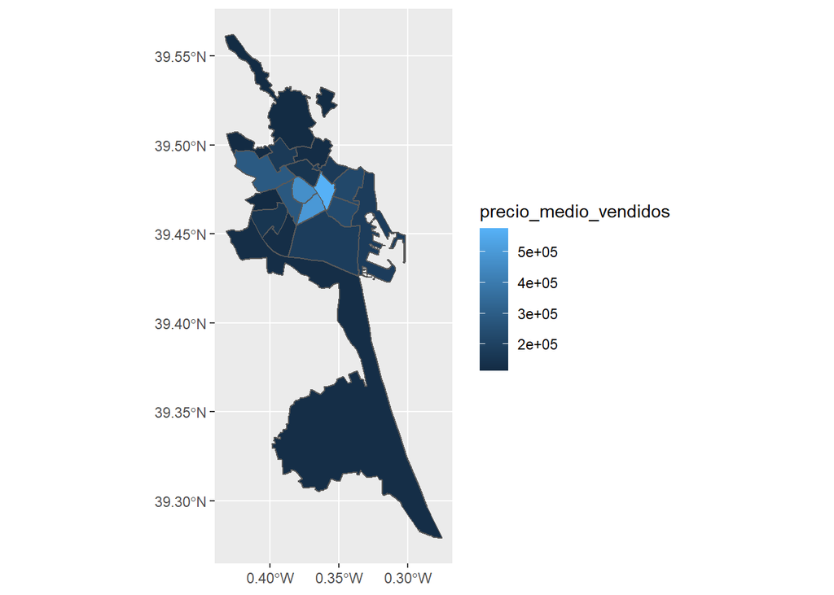

```r
dias = data.frame(distrito = distritos$distrito, precio_medio_vendidos = distritos$precio_medio_vendidos)

drawing_data <-
  peninbal_shp3 %>%
  mutate(distrito = name) %>%
  left_join(dias, by = 'distrito')


drawing_data %>%
  ggplot() +
  aes(fill = `precio_medio_vendidos`) +
  geom_sf()
```

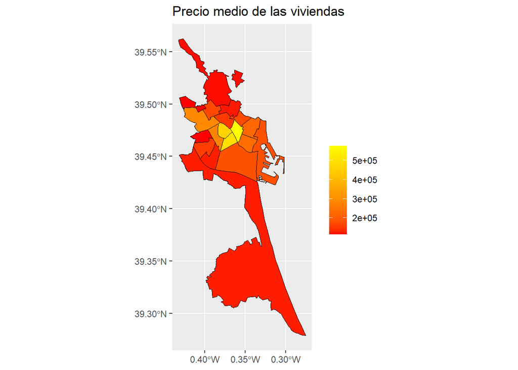

```r
map <-
  drawing_data %>%
  ggplot() +
  aes(fill = `precio_medio_vendidos`) +
  geom_sf(color = "black", size = 0.1) +
  ggtitle("Precio medio de las viviendas")

map + scale_fill_gradientn(colours = c('red', 'yellow'), name = NULL)
```

## 3.3 Días medios de venta de una casa

En cuanto a esta variable, pensamos que era interesante, pues si una casa se vende rápido podría tener un precio elevado.

La visualización nos ha generado muchas curiosidades, pues parece que en el norte de la ciudad los pisos se vendan muy rápido, mientras que en el sur tardan, de media, 10 días más en venderse.

Hemos concluido que las casas baratas del norte puede que se vendan enseguida a gente del barrio, pero que los compradores se piensen más el adquirir una casa cara.

También en el sur están construyendo nuevas viviendas, que apenas están amuebladas y probablemente los compradores no tengan una visión clara del piso y estén dubitativos.

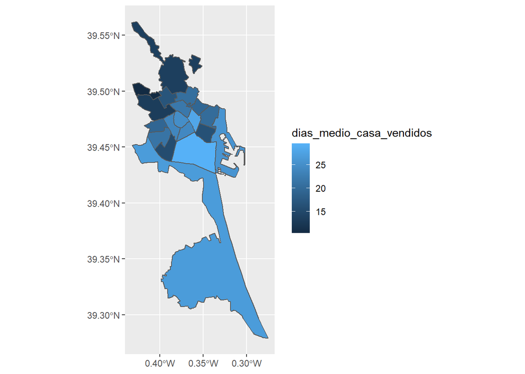

```r
dias = data.frame(distrito = distritos$distrito, dias_medio_casa_vendidos = distritos$dias_medio_casa_vendidos)

drawing_data <-
  peninbal_shp3 %>%
  mutate(distrito = name) %>%
  left_join(dias, by = 'distrito')


drawing_data %>%
  ggplot() +
  aes(fill = `dias_medio_casa_vendidos`) +
  geom_sf()
```

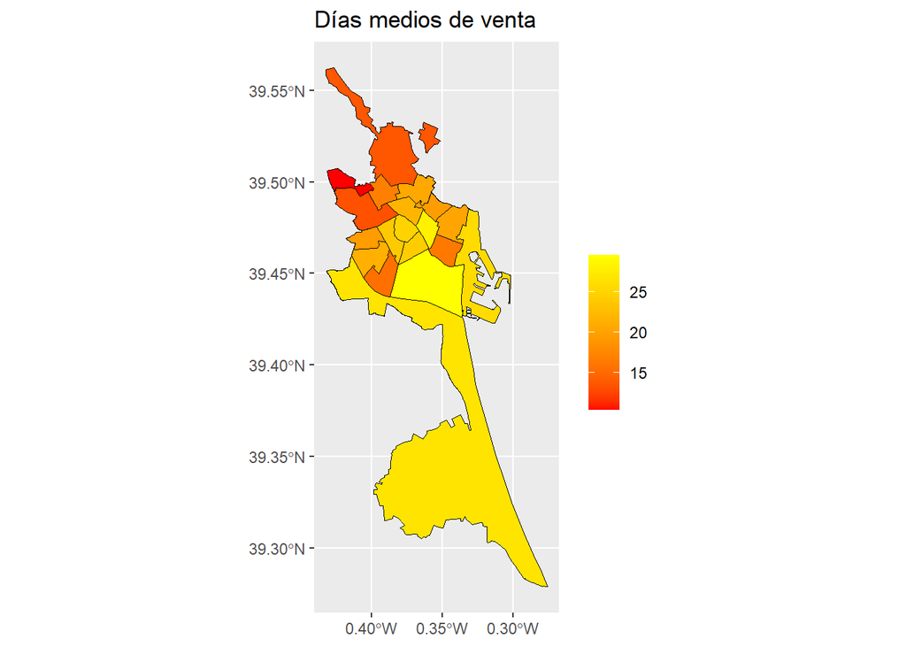

```r
map <-
  drawing_data %>%
  ggplot() +
  aes(fill = `dias_medio_casa_vendidos`) +
  geom_sf(color = "black", size = 0.1) +
  ggtitle("Días medios de venta")

map + scale_fill_gradientn(colours = c('red', 'yellow'), name = NULL)
```

## 3.4 Días medio venta locales

Esta variable se utilizó para ver el movimiento comercial de los distritos, pues si un distrito es muy cambiante, puede que haya más actividad inmobiliaria.

Observando la vsualización, podemos concluir una clara correlación entre los precios finales y el movimiento de locales: cuánto más movimiento comercial y de bajos, más caras son las viviendas de ese distrito.

De nuevo, Poblats del Nord, al ser pedanías, apenas tiene movimiento de locales, y por ello no tiene mucho movimiento de venta de viviendas.

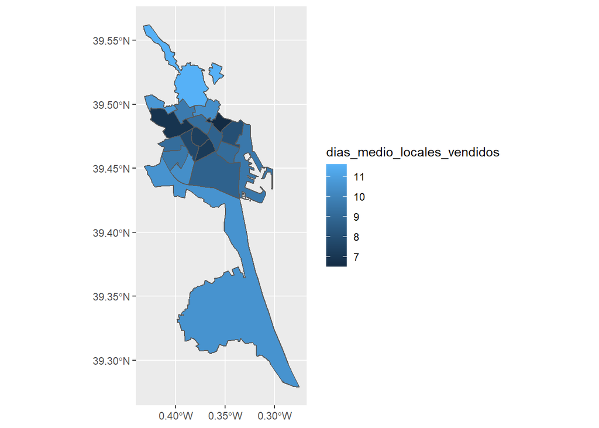

```r
dias = data.frame(distrito = distritos$distrito, dias_medio_locales_vendidos = distritos$dias_medio_locales_vendidos)

drawing_data <-
  peninbal_shp3 %>%
  mutate(distrito = name) %>%
  left_join(dias, by = 'distrito')


drawing_data %>%
  ggplot() +
  aes(fill = `dias_medio_locales_vendidos`) +
  geom_sf()
```

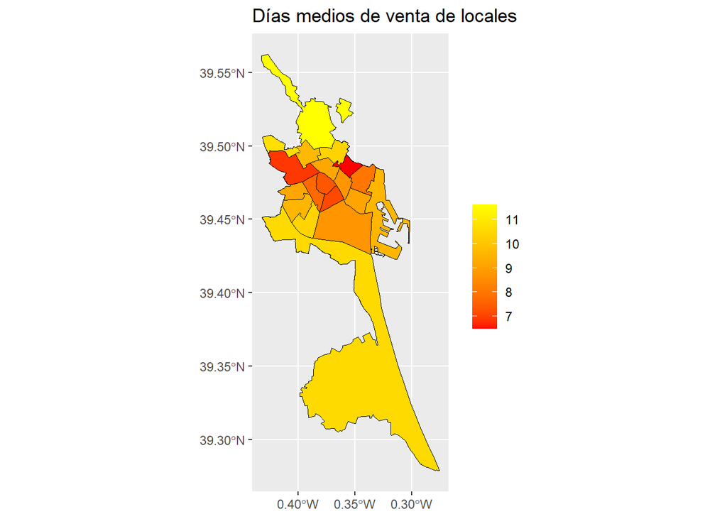

```r
map <-
  drawing_data %>%
  ggplot() +
  aes(fill = `dias_medio_locales_vendidos`) +
  geom_sf(color = "black", size = 0.1) +
  ggtitle("Días medios de venta de locales")

map + scale_fill_gradientn(colours = c('red', 'yellow'), name = NULL)
```

## 3.5 Media m2

Si hacemos la media de m2 graficados anteriormente obtenemos esta variable. Con ello, podemos clasificar a los distritos, según tengan pisos grandes, pequeños o medianos.

Entre los distritos con pisos grandes encontramos los distritos céntricos, como se suponía.

Y los demás barrios se reparten homogéneamente entre medianos y pequeños. En general en estos distritos las casas no superan los 130 m2, por lo que si se desea adquirir una casa con más m2, se recomienda comprar en los distritos del centro.

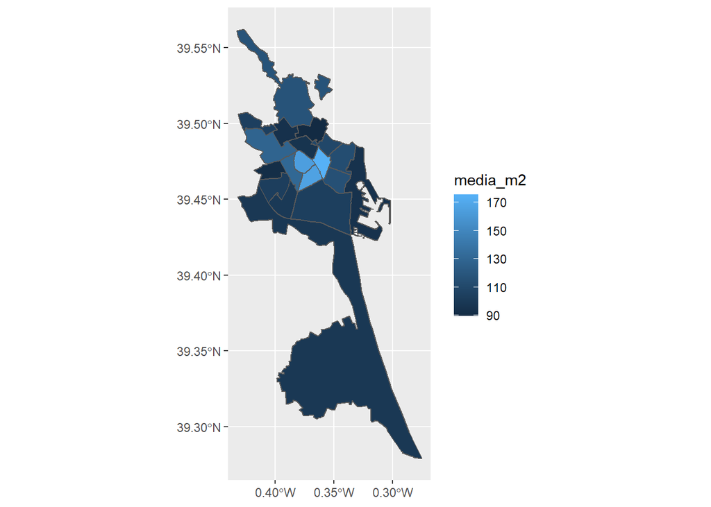

```r
med_m2 = data.frame(distrito = distritos$distrito, media_m2 = distritos$media_m2)

drawing_data <-
  peninbal_shp3 %>%
  mutate(distrito = name) %>%
  left_join(med_m2, by = 'distrito')


drawing_data %>%
  ggplot() +
  aes(fill = `media_m2`) +
  geom_sf()
```

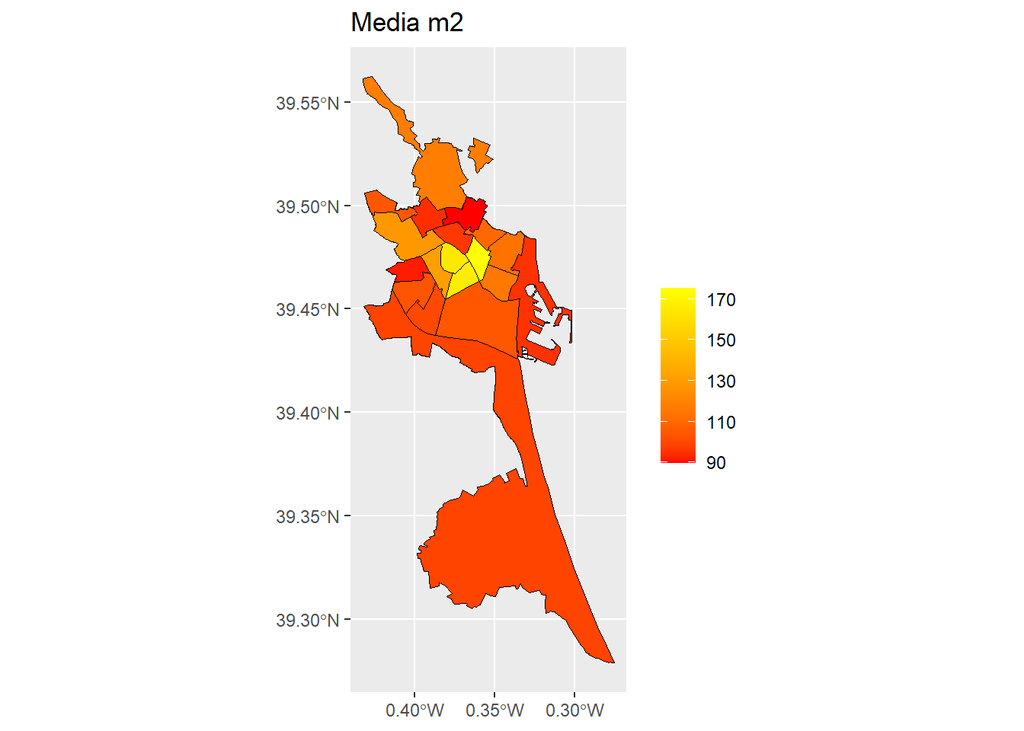

```r
map <-
  drawing_data %>%
  ggplot() +
  aes(fill = `media_m2`) +
  geom_sf(color = "black", size = 0.1) +
  ggtitle("Media m2")

map + scale_fill_gradientn(colours = c('red', 'yellow'), name = NULL)
```

## 3.6 Media habitaciones

Si nos fijamos en la media de habitaciones de cada distrito, encontramos varios distritos que superan las 3 habitaciones, por lo que tienen casas grandes. Entre ellos, los céntricos, y los de residencia de estudiantes. Estos últimos probablemente contengan viviendas más antiguas, con más habitaciones para compratir entre estudiantes.

También sorprende las habitaciones de Poblats del Nord. Un posible motivo puede ser la gran cantidad de casas particulares.

Lo mismo podríamos pensar con Poblats del Sud, pero al ser una zona de más veraneo, es posible que las casas sean más pequeñas, pues solo son para un pequeño periodo de tiempo (el verano).

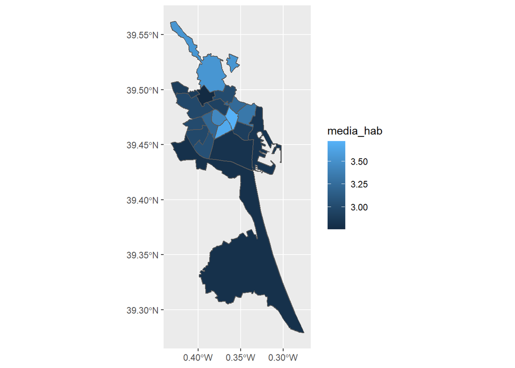

```r
hab = data.frame(distrito = distritos$distrito, media_hab = distritos$media_hab)

drawing_data <-
  peninbal_shp3 %>%
  mutate(distrito = name) %>%
  left_join(hab, by = 'distrito')


drawing_data %>%
  ggplot() +
  aes(fill = `media_hab`) +
  geom_sf()
```

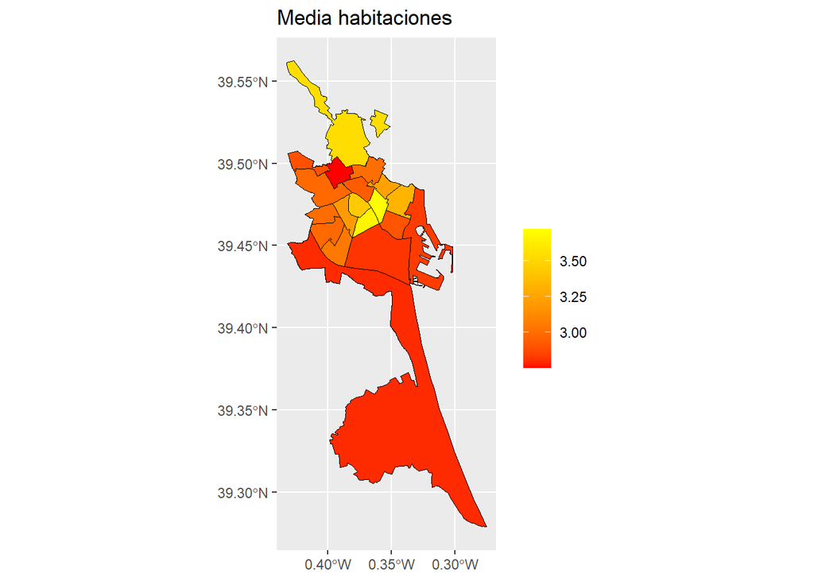

```r
map <-
  drawing_data %>%
  ggplot() +
  aes(fill = `media_hab`) +
  geom_sf(color = "black", size = 0.1) +
  ggtitle("Media habitaciones")

map + scale_fill_gradientn(colours = c('red', 'yellow'), name = NULL)
```

## 3.7 Media baños

La media de baños tampoco sorprende. Como de normal, los barrios más caros y con casas más grandes disponen de mayor número de baños.

Los barrios más periféricos apenas llegan a una media de dos.

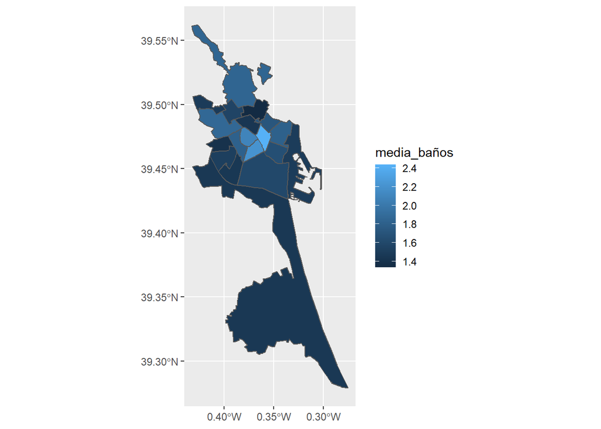

```r
ba = data.frame(distrito = distritos$distrito, media_baños = distritos$media_baños)

drawing_data <-
  peninbal_shp3 %>%
  mutate(distrito = name) %>%
  left_join(ba, by = 'distrito')


drawing_data %>%
  ggplot() +
  aes(fill = `media_baños`) +
  geom_sf()
```

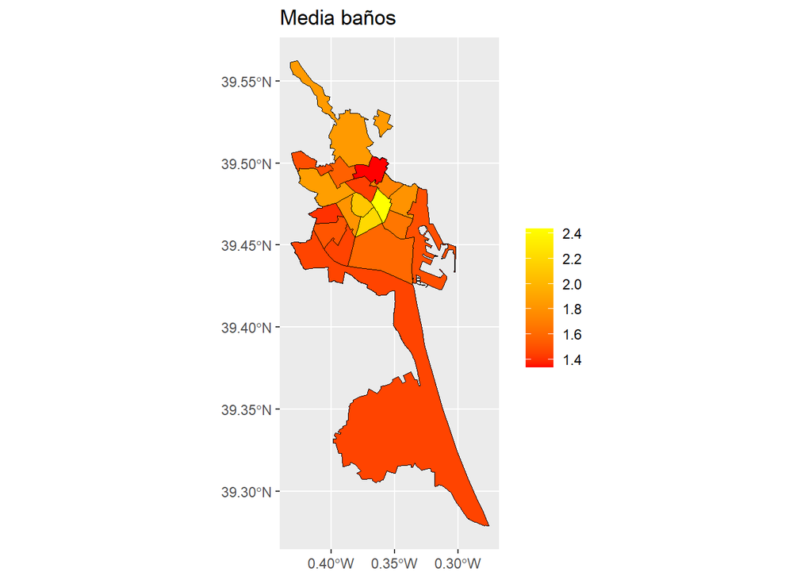

```r
map <-
  drawing_data %>%
  ggplot() +
  aes(fill = `media_baños`) +
  geom_sf(color = "black", size = 0.1) +
  ggtitle("Media baños")

map + scale_fill_gradientn(colours = c('red', 'yellow'), name = NULL)
```

## 3.8 Media plantas

La media de plantas proporciona una visualización muy interesante.

Primero de todo, confirmamos las casas particulares de Poblats del Nord, pues su altura está en torno a los dos pisos.

Por otro lado, obervamos que Valencia es una ciudad cuyos pisos tienen en torno a 4 plantas, lo que no es ni muy bajo ni muy alto. Podemmos decir que no está muy masificada.

En cuanto a los pisos con media en torno a 6, se encuentran en los distritos de Campanar, el Pla del Real y Algirós. El primero, como yo hemos mencionado anteriormente, está en plena construcción de pisos nuevos, concretamente de urbanizaciones. Ese es el motivo de la altura. El segundo y el tercero, también disponen de varias urbanizaciones y bloques de edificios.

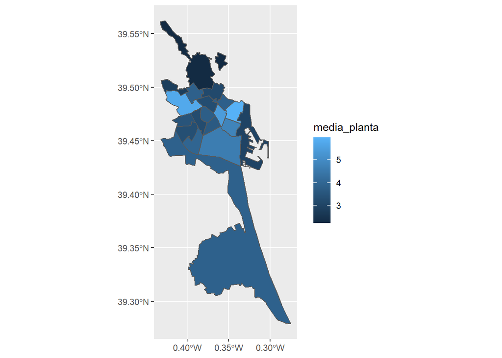

```r
pl = data.frame(distrito = distritos$distrito, media_planta = distritos$media_planta)

drawing_data <-
  peninbal_shp3 %>%
  mutate(distrito = name) %>%
  left_join(pl, by = 'distrito')


drawing_data %>%
  ggplot() +
  aes(fill = `media_planta`) +
  geom_sf()
```

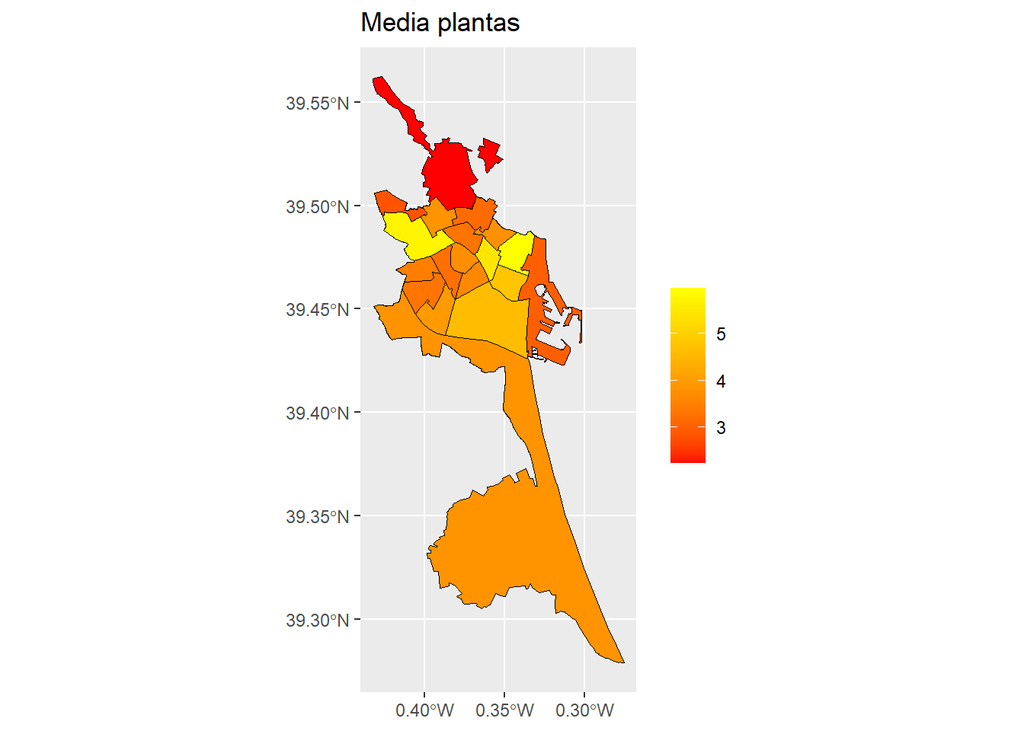

```r
map <-
  drawing_data %>%
  ggplot() +
  aes(fill = `media_planta`) +
  geom_sf(color = "black", size = 0.1) +
  ggtitle("Media plantas")

map + scale_fill_gradientn(colours = c('red', 'yellow'), name = NULL)
```

## 3.9 Renta distritos

Esta variable ha sido sacada de la renta bruta de 2019 de Valencia, recogida por el INE.

```r
distritos = read.csv('Renta_distrito.csv', sep = ';', header = FALSE)

colnames(distritos) = c('distrito', 'numero', 'renta')
distritos$renta = gsub(',0', '', distritos$renta)

distritos$distrito[distritos$distrito == 'La Saïdia'] = 'La Saidia'
distritos$distrito[distritos$distrito == 'Poblats Marítims'] = 'Poblats Maritims'
distritos$distrito[distritos$distrito == 'Algirós'] = 'Algiros'
distritos$distrito[distritos$distrito == 'Jesús'] = 'Jesus'
distritos$distrito[distritos$distrito == "L'Eixample"] = "l'Eixample"
distritos$distrito[distritos$distrito == "L'Olivereta"] = "l'Olivereta"


distritos$renta = as.numeric(distritos$renta)
```

Esta variable la hemos utilizado para confirmar los distritos más ricos (y por tanto que puedan tener pisos más caros) y los más pobres (que tengan casas más baratas).

Entre los ricos, deducimos que son Ciutat Vella, Pla del Real y L’Eixample. Hemos comprobado que estos eran los distritos que mejores características tenían (más caros, más baños, más habitaciones…)

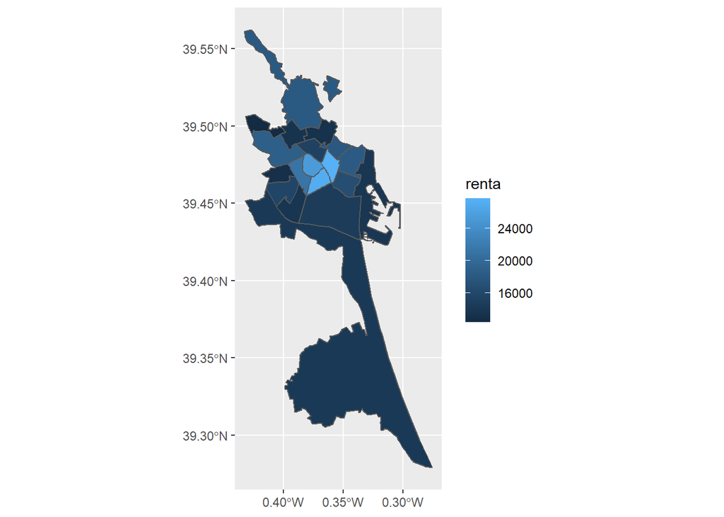

```r
renta = data.frame(distrito = distritos$distrito, renta = distritos$renta)

drawing_data <-
  peninbal_shp3 %>%
  mutate(distrito = name) %>%
  left_join(renta, by = 'distrito')


drawing_data %>%
  ggplot() +
  aes(fill = `renta`) +
  geom_sf()
```

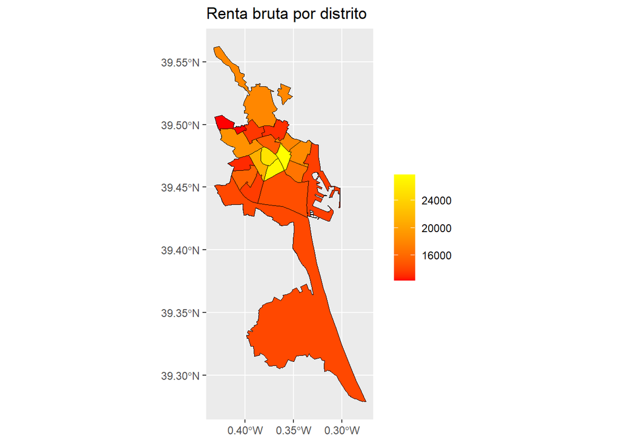

```r
map <-
  drawing_data %>%
  ggplot() +
  aes(fill = `renta`) +
  geom_sf(color = "black", size = 0.1) +
  ggtitle("Renta bruta por distrito")

map + scale_fill_gradientn(colours = c('red', 'yellow'), name = NULL)
```

# 4 Otros factores

Exploramos el resto de variables para comprobar si el transporte, las zonas verdes, los colegios etc influyen en el hecho de ser mejores o peores distritos.

## 4.1 Metro, colegios, universidades y centros comerciales

A continuación se representan las paradas de metro de metroValencia, los mejores 20 colegios (según la nota de la fase obligatoria de la Selectividad), las universidades (para ver las zonas estudiantiles) y los centros comerciales (con el fin de estudiar el movimiento de distrito).

```r
metro = read.csv('paradas_metrovalencia.csv', sep = ';')

la = metro$stop_lat
lo = metro$stop_lon

m = data.frame(lat = la, lng = lo, tipo = 'metrovalencia')

univ = read.csv('Universidades.csv', sep = ';')

la = univ$Latitud
lo = univ$Longitud

u = data.frame(lat = la, lng = lo, tipo = 'universidad')

cc = read.csv('Centros_Comerciales.csv', sep = ';')

la = cc$Latitud
lo = cc$Longitud

c = data.frame(lat = la, lng = lo, tipo = 'centro_comercial')

colegios = read.csv('top20colegios.csv', sep = ',')

la = colegios$latitud_centro
lo = colegios$longitud_centro

g = data.frame(lat = la, lng = lo, tipo = 'colegio')

final = rbind(m, u, c, g)
final$tipo = factor(final$tipo)
```

Por lo que respecta al metro, no creemos que sea un factor decisivo, pues la mayoría de la ciudad tiene cerca una parada.

En cuanto a los colegios, también parece que se distribuyan de una forma homogénea.

Las universidades tampoco contribuyen al precio de las casas, solo a caracterizar los dsitritos como zonas universitarias, y con pisos más altos.

Y por último los centros comerciales se encuentran en torno a las zonas más nuevas de Valencia (Poblats Marítims, Quatre Carreres, Campanar y Alboraia).

```r
pale = c('#53D14F', '#4FBFD1', '#E74917', '#E0B20A')

leaflet(final) %>%
  addTiles() %>%
  addCircles(weight = 6, color = pale[final$tipo], radius = 5, popup = final$tipo) %>%
  addLegend(position = "bottomleft" ,colors =pale,
            labels = paste("->", c('centro_comercial', 'top20colegios','metro','universidad')), title = 'Etiquetas')
```

```
## Assuming "lng" and "lat" are longitude and latitude, respectively
```

[interactive chart not shown]

## 4.2 Locales

También hemos graficado llamlongitud y latitud de los locales (de los cuales hemos sacado los días medios que tardaban en venderse).

Este mapa lo hemos hecho mediante clustering, de forma que se puede ver los locales por distrito (ampliando).

```r
locales = read.csv('localesR.csv', sep = ';')


la = locales$latitude
lo = locales$longitude

l = data.frame(lat = la, lng = lo, tipo = 'locales')

leaflet(l) %>%
  addTiles() %>%
  addMarkers(clusterOptions = markerClusterOptions(l))
```

```
## Assuming "lng" and "lat" are longitude and latitude, respectively
```

[interactive chart not shown]

## 4.3 Colegios por ránking

Por último, clasificamos los colegios por ránking (siendo 0 el mejor y 19 el peor).

```r
colegios = read.csv('top20colegios.csv', sep = ',')

la = colegios$latitud_centro
lo = colegios$longitud_centro

pale <- rainbow(20)

c = data.frame(lat = la, lng = lo)


leaflet(c) %>%
  addTiles() %>%
  addCircles(weight = 5, color = pale[colegios$X], radius = 30, popup = colegios$X) %>%
  addLegend(position = "bottomleft" ,colors = pale,
            labels = paste("->", colegios$X), title = 'Etiquetas')
```

[interactive chart not shown]